# Seastars

Genoa Sullaway

8/27/2020

## Purpose

- to plot seastar patterns in abundance and occurance, look at potential predator prey relationships and look at size distributions (not done yet).

## Summary Notes

- A lot of seastars in 2015 – Is this a 2015 methods thing?
- the 2015 thing looks to matter a lot, it drives alot of patterns between predator prey that don’t appear as strongly once I remove 2015.
- A lot of YOY seastars in 2017
- Looks like there is more to explore with seastars and prey… Species and site specific relationships ?

## Site-Level Abundance

- Plot patterns of seastar abundance by site and year using site-level data

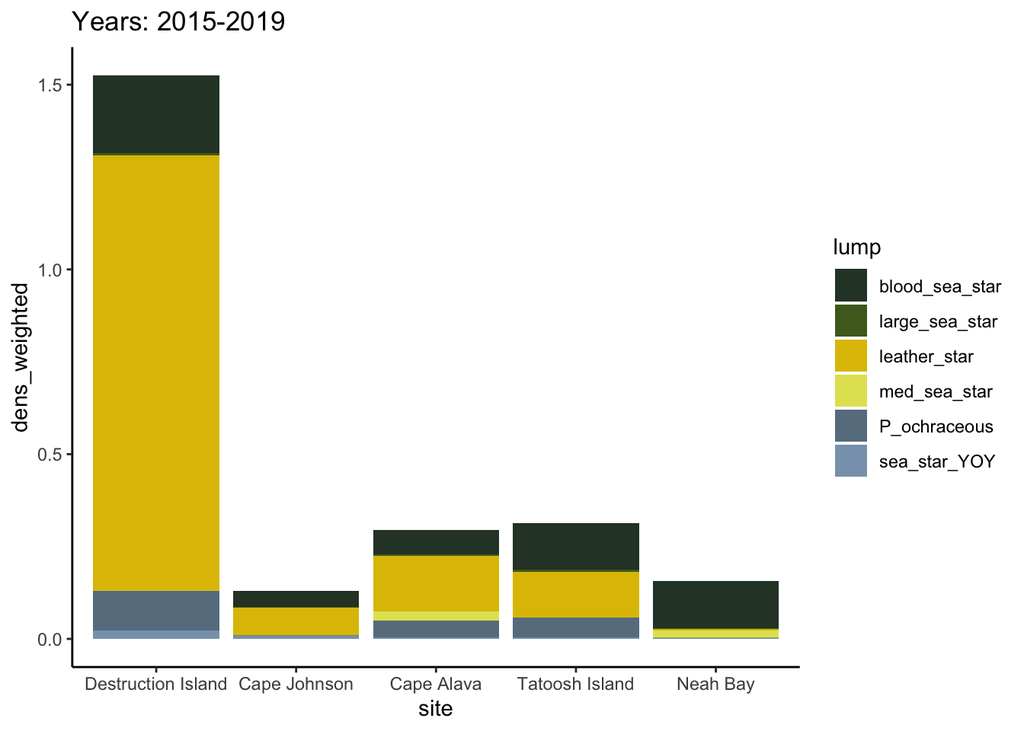

```r
inverts <- read_csv(here('Flagstone paper','Data','invert_swath_sitelevel.csv'))
seastars_site <- inverts %>%
  mutate(lump = case_when(lump %in% c("brood_sea_star", "blood_star")~ "blood_sea_star",
                          lump %in% c("med_seastar")~ "med_sea_star",
                          TRUE ~ lump )) %>%
  dplyr::filter(lump %in% seastar_spp,
         !site %in% c("Anderson Point", "Point of the Arches","Rock 305", "Chibadehl Rocks","Teahwhit Head")) %>%
  dplyr::select(year,site,lump,dens_weighted,se_w)

#look at community across sites using a stacked bar and means across years
seastars_site %>%
  group_by(site,lump) %>%
  summarise(dens_weighted = mean(dens_weighted)) %>%
  ungroup() %>%
  mutate(site = factor(site, levels =site_factor)) %>%
ggplot(aes(fill=lump, y=dens_weighted, x=site)) +
    geom_bar(position="stack", stat="identity") +
  scale_fill_manual(values = color6) +
  ggtitle("Years: 2015-2019") +
  theme_classic()
```

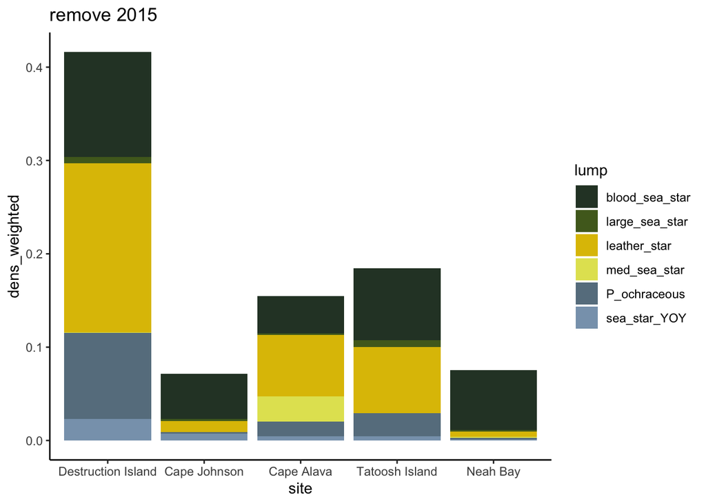

```r
#What Happens if we remove 2015? -- look at community across sites and years using a stacked bar
seastars_site %>%
  filter(!year == 2015) %>%
  group_by(site,lump) %>%
  summarise(dens_weighted = mean(dens_weighted)) %>%
  ungroup() %>%
  mutate(site = factor(site, levels =c("Destruction Island","Cape Johnson","Cape Alava","Tatoosh Island" , "Neah Bay" ))) %>%
ggplot(aes(fill=lump, y=dens_weighted, x=site)) +
    geom_bar(position="stack", stat="identity") +
  scale_fill_manual(values = color6) +
  ggtitle("remove 2015")+
    theme_classic()
```

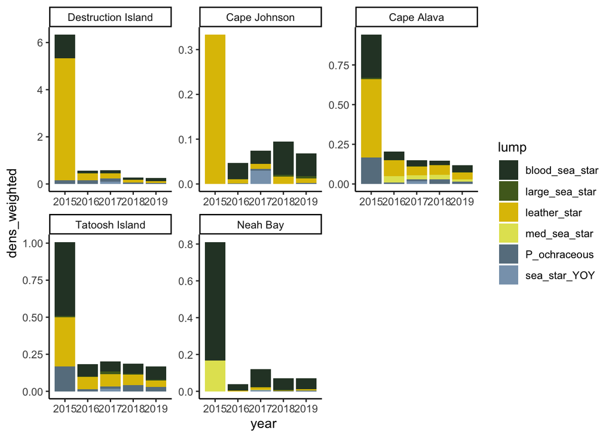

```r
#How do sites change across time?
seastars_site %>%
  group_by(year,site,lump) %>%
  summarise(dens_weighted = mean(dens_weighted)) %>% #take mean across zones
  ungroup() %>%
  mutate(site = factor(site, levels =c("Destruction Island","Cape Johnson","Cape Alava","Tatoosh Island" , "Neah Bay" ))) %>%
ggplot(aes(fill=lump, y=dens_weighted, x=year)) +
    geom_bar(position="stack", stat="identity") +
  scale_fill_manual(values = color6) +
  facet_wrap(~site,scales = "free" )+
  theme_classic()
```

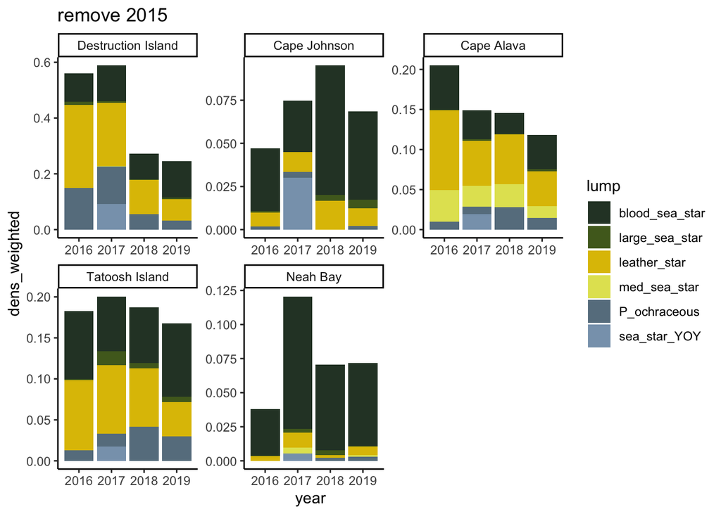

```r
#REMOVE 2015 -- look at stacked bar for each site across years
seastars_site %>%
  filter(!year == 2015) %>%
  group_by(year,site,lump) %>%
  summarise(dens_weighted = mean(dens_weighted)) %>% #take mean across zones
  ungroup() %>%
  mutate(site = factor(site, levels =c("Destruction Island","Cape Johnson","Cape Alava","Tatoosh Island" , "Neah Bay" ))) %>%
ggplot(aes(fill=lump, y=dens_weighted, x=year)) +
    geom_bar(position="stack", stat="identity") +
  scale_fill_manual(values = color6) +
  ggtitle("remove 2015") +
  facet_wrap(~site,scales = "free") +
  theme_classic()
```

## Characterisize seastars and prey by transect using transect-level data

- Get seastar diets, match them with prey
- Look at transect,zone and site level relationships of species with their specific prey groups
- Which species is most likely to each urchins? make a plot that focuses on that relatioship
- Right now considering bivalves and urchins as prey – but need to research this a bit

```r
#load data - filter to species, remove some 2015 sites that werent surveyed in other years, fix some species names
inverts <- read_csv(here('Flagstone paper','Data','invert_swath_transectlevel.csv'))

seastars <- inverts %>%
  mutate(lump = case_when(lump %in% c("brood_sea_star", "blood_star")~ "blood_sea_star",
                          lump %in% c("med_seastar")~ "med_sea_star",
                          TRUE ~ lump )) %>%
  dplyr::filter(lump %in% seastar_spp,
         !site %in% c("Anderson Point", "Point of the Arches","Rock 305", "Chibadehl Rocks","Teahwhit Head")) %>%
  dplyr::select(year,site,zone,lump,transect,dens_weighted,se_w) %>%
   mutate(pred_prey_group = "seastar")

#unique(inverts$lump)

seastar_prey <- inverts %>%
  dplyr::filter(lump %in% c("bivalve","green_urchin","shelled_mollusk", "purple_urchin","chiton",
                            "shelled_gastropod","red_urchin"),
                !site %in% c("Anderson Point", "Point of the Arches","Rock 305", "Chibadehl Rocks","Teahwhit Head")) %>%
  dplyr::select(year,site,zone,lump,transect,dens_weighted,se_w) %>%
  mutate(pred_prey_group = "prey")

seastar.pred.prey <- full_join(seastars,seastar_prey)
```

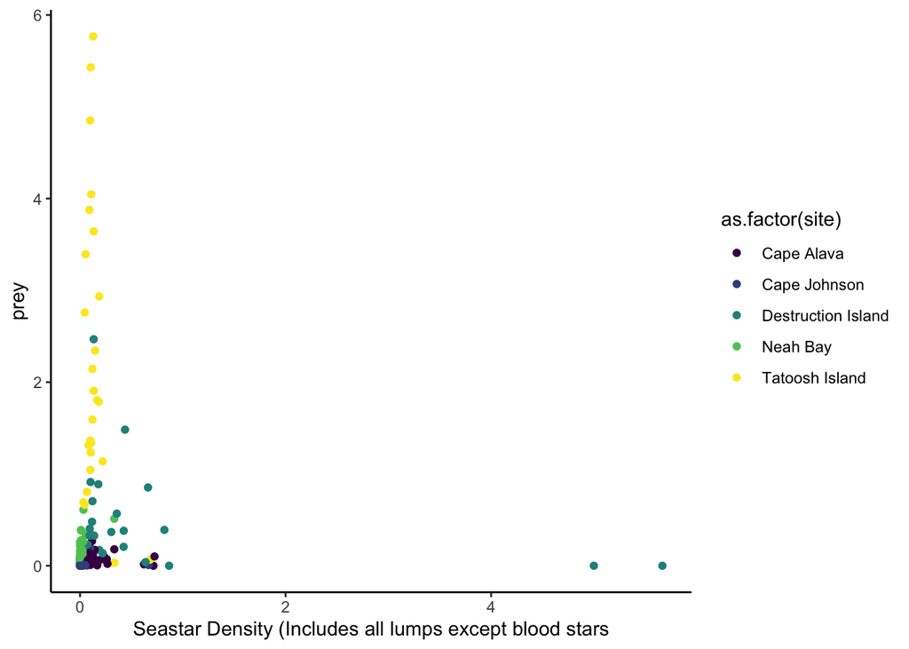

```r
seastar.pred.prey %>%
  filter(!lump %in% c( "blood_sea_star")) %>%
   group_by(year,site,zone,transect,pred_prey_group) %>%
   summarise(dens_weighted=sum(dens_weighted)) %>%
   spread(pred_prey_group, dens_weighted) %>%
   ungroup() %>%
   ggplot() +
   geom_point(aes(x=seastar, y = prey,color = as.factor(site))) +
   scale_color_viridis(discrete = T)  +
  xlab("Seastar Density (Includes all lumps except blood stars") +
  theme_classic()
```

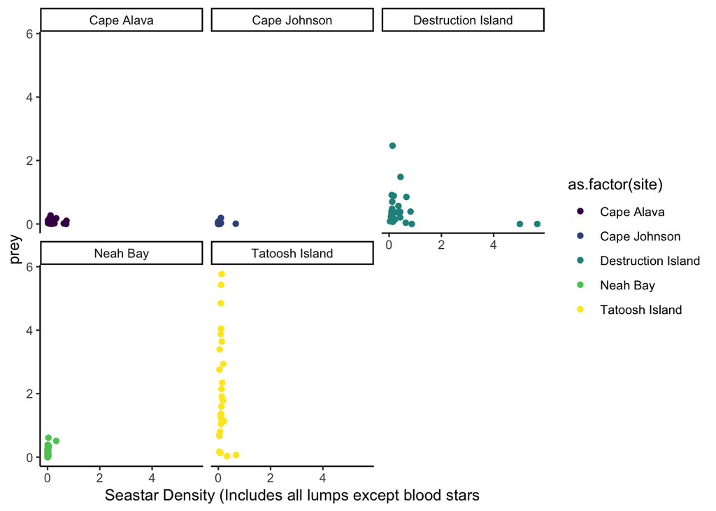

```r
seastar.pred.prey %>%
  filter(!lump %in% c( "blood_sea_star")) %>%
   group_by(year,site,zone,transect,pred_prey_group) %>%
   summarise(dens_weighted=sum(dens_weighted)) %>%
   spread(pred_prey_group, dens_weighted) %>%
   ungroup() %>%
   ggplot() +
   geom_point(aes(x=seastar, y = prey,color = as.factor(site))) +
   scale_color_viridis(discrete = T)  +
  xlab("Seastar Density (Includes all lumps except blood stars") +
    facet_wrap(~site ) +
  theme_classic()
```

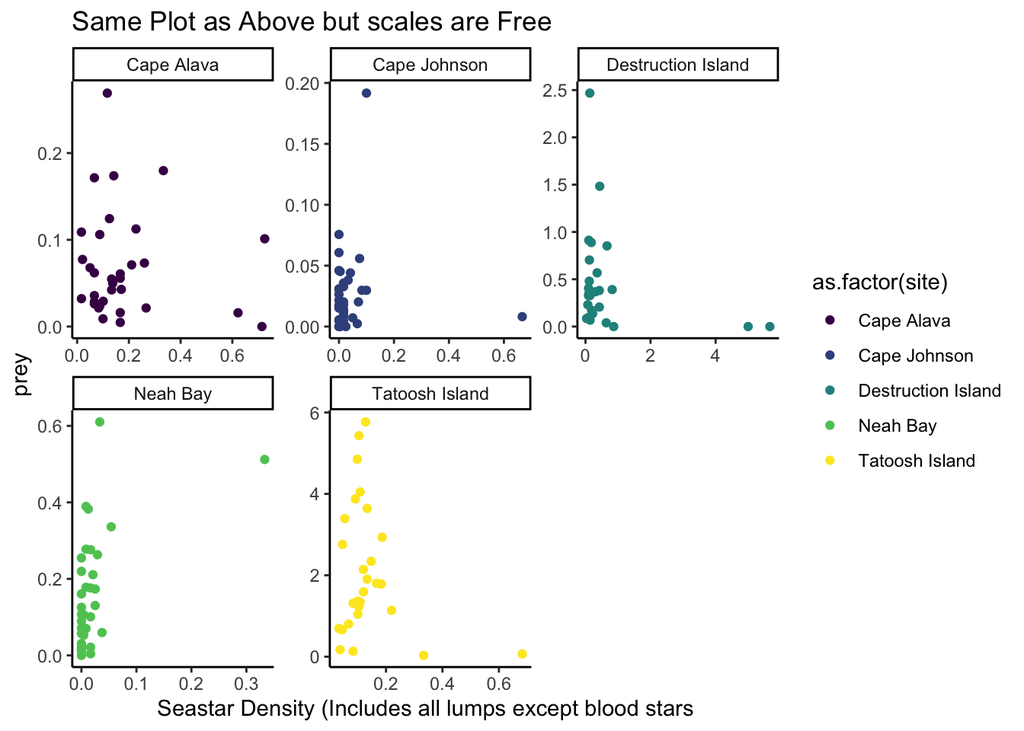

```r
seastar.pred.prey %>%
  filter(!lump %in% c( "blood_sea_star")) %>%
   group_by(year,site,zone,transect,pred_prey_group) %>%
   summarise(dens_weighted=sum(dens_weighted)) %>%
   spread(pred_prey_group, dens_weighted) %>%
   ungroup() %>%
   ggplot() +
   geom_point(aes(x=seastar, y = prey,color = as.factor(site))) +
   scale_color_viridis(discrete = T)  +
  xlab("Seastar Density (Includes all lumps except blood stars") +
  ggtitle("Same Plot as Above but scales are Free") +
    facet_wrap(~site,scales = "free" ) +
  theme_classic()
```